# homework6

Michael Mila

2/28/2022

## Team Members

- Michael Mila
- Wei Hern Lim

## Github link

https://github.com/mmila38/ds202-hw6

```r
library(tidyverse)
```

## Read in data

```r
HAPPY <- readRDS("data/HAPPY.rds")
```

# Cleaning data

## Replacing IAP, DK, NA with “NA”

```r
HAPPY = replace(HAPPY, HAPPY == "IAP", NA)
HAPPY = replace(HAPPY, HAPPY == "DK", NA)
HAPPY = replace(HAPPY, HAPPY == "NA", NA)
```

## Changing “89 AND OLDER” to 89, and assuming the variable should be numeric

```r
HAPPY <- HAPPY %>% mutate(
  age = replace(AGE, AGE == "89 AND OLDER", 89),
  age = as.numeric(age)
) %>% select(-AGE)
str(HAPPY)
```

```
## 'data.frame':    62466 obs. of  11 variables:
##  $ HAPPY   : chr  "NOT TOO HAPPY" "NOT TOO HAPPY" "PRETTY HAPPY" "NOT TOO HAPPY" ...
##  $ YEAR    : int  1972 1972 1972 1972 1972 1972 1972 1972 1972 1972 ...
##  $ SEX     : chr  "FEMALE" "MALE" "FEMALE" "FEMALE" ...
##  $ MARITAL : chr  "NEVER MARRIED" "MARRIED" "MARRIED" "MARRIED" ...
##  $ DEGREE  : chr  "BACHELOR" "LT HIGH SCHOOL" "HIGH SCHOOL" "BACHELOR" ...
##  $ FINRELA : chr  "AVERAGE" "ABOVE AVERAGE" "AVERAGE" "AVERAGE" ...
##  $ HEALTH  : chr  "GOOD" "FAIR" "EXCELLENT" "GOOD" ...
##  $ WTSSALL : num  0.445 0.889 0.889 0.889 0.889 ...
##  $ PARTYID : chr  "IND,NEAR DEM" "NOT STR DEMOCRAT" "INDEPENDENT" "NOT STR DEMOCRAT" ...
##  $ POLVIEWS: chr  NA NA NA NA ...
##  $ age     : num  23 70 48 27 61 26 28 27 21 30 ...
```

## Bring all levels of factor into a sensible order.

### Degree

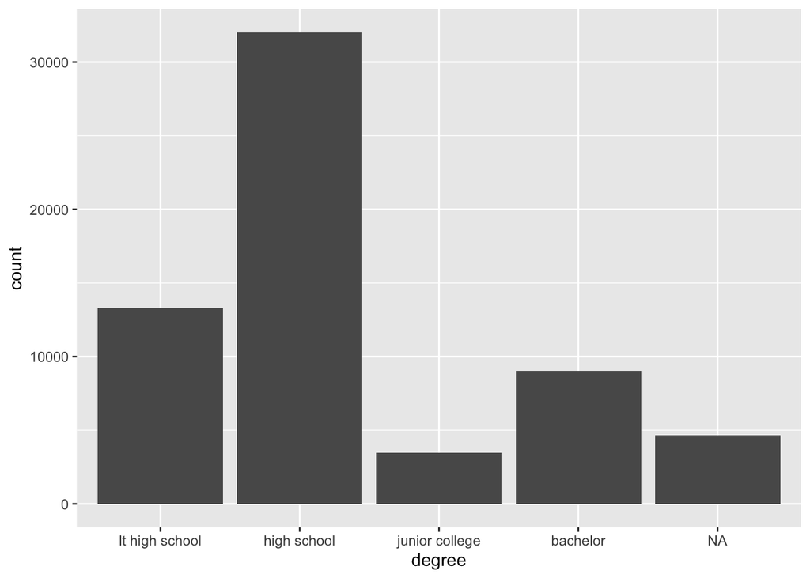

```r
HAPPY <- HAPPY %>% mutate(
  degree = factor(tolower(DEGREE)),
  degree = factor(degree, levels=c("lt high school", "high school", "junior college", "bachelor", "graduate school"))
) %>% select(-DEGREE)

HAPPY %>% ggplot(aes(x = degree)) + geom_bar()
```

```r
HAPPY <- HAPPY %>% mutate(
  HAPPY = as.factor(HAPPY),
  SEX = as.factor(SEX),
  MARITAL = as.factor(MARITAL),
  FINRELA = as.factor(FINRELA),
  HEALTH = as.factor(HEALTH),
  PARTYID = as.factor(PARTYID)
)
str(HAPPY)
```

```
## 'data.frame':    62466 obs. of  11 variables:
##  $ HAPPY   : Factor w/ 3 levels "NOT TOO HAPPY",..: 1 1 2 1 2 2 1 1 2 2 ...
##  $ YEAR    : int  1972 1972 1972 1972 1972 1972 1972 1972 1972 1972 ...
##  $ SEX     : Factor w/ 2 levels "FEMALE","MALE": 1 2 1 1 1 2 2 2 1 1 ...
##  $ MARITAL : Factor w/ 5 levels "DIVORCED","MARRIED",..: 3 2 2 2 2 3 1 3 3 2 ...
##  $ FINRELA : Factor w/ 5 levels "ABOVE AVERAGE",..: 2 1 2 2 1 1 1 2 2 3 ...
##  $ HEALTH  : Factor w/ 4 levels "EXCELLENT","FAIR",..: 3 2 1 3 3 3 1 3 1 2 ...
##  $ WTSSALL : num  0.445 0.889 0.889 0.889 0.889 ...
##  $ PARTYID : Factor w/ 8 levels "IND,NEAR DEM",..: 1 4 3 4 7 1 1 1 7 7 ...
##  $ POLVIEWS: chr  NA NA NA NA ...
##  $ age     : num  23 70 48 27 61 26 28 27 21 30 ...
##  $ degree  : Factor w/ 5 levels "lt high school",..: 4 1 2 4 2 2 2 4 2 2 ...
```

### Changing levels of marital status and finanical relationship

```r
HAPPY <- HAPPY %>% mutate(
  marital = factor(tolower(MARITAL)),
  marital = factor(marital, levels=c("never married", "seperated", "married", "divorced", "widowed"))
) %>% select(-MARITAL)

levels(HAPPY$marital)
```

```
## [1] "never married" "seperated"     "married"       "divorced"
## [5] "widowed"
```

```r
HAPPY <- HAPPY %>% mutate(
  finrela = factor(tolower(FINRELA)),
  finrela = factor(finrela, levels=c("far below average", "below average", "average", "above average", "far above average"))
) %>% select(-FINRELA)

levels(HAPPY$finrela)
```

```
## [1] "far below average" "below average"     "average"
## [4] "above average"     "far above average"
```

### Changing of levels of health to make it from poor to excellent

```r
HAPPY <- HAPPY %>% mutate(
  health = factor(tolower(HEALTH)),
  health = factor(health, levels=c("poor", "fair", "good", "excellent"))
) %>% select(-HEALTH)

levels(HAPPY$health)
```

```
## [1] "poor"      "fair"      "good"      "excellent"
```

## How is happiness related to health? How does sex also pay a factor? - Question by Michael Mila

```r
happy.health.sex = HAPPY %>% group_by(health, SEX) %>% summarise(m.happy = mean(as.numeric(HAPPY), na.rm = TRUE)) %>% arrange(m.happy)
```

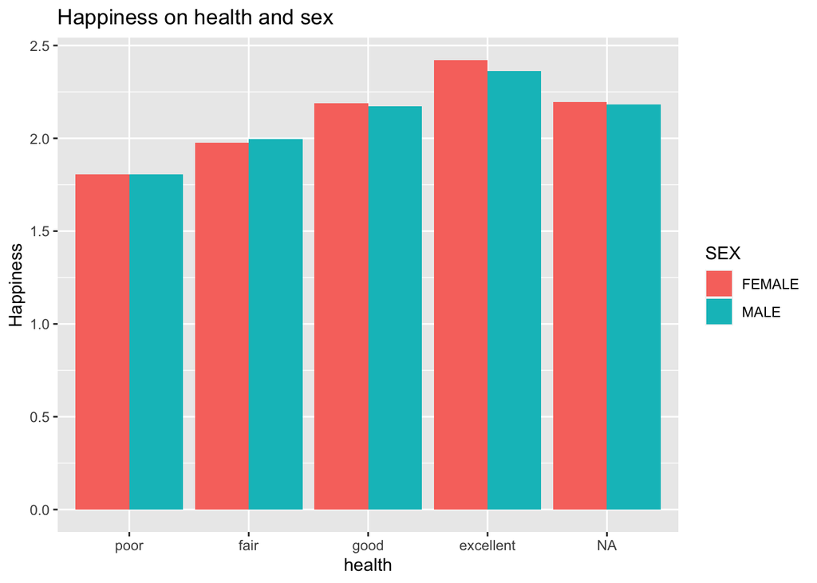

```r
happy.health.sex %>% ggplot(aes(x = health, fill = SEX)) +
  geom_bar(aes(weight = m.happy), position = position_dodge()) +
  labs(title = "Happiness on health and sex", y = "Happiness")
```

It looks like for both male and females, a better health status is related to higher levels of happiness. There appears to be no difference between males and females level of happiness when investigating their health. There is a very small difference in happiness levels between gender in the excellent health category, but it is not large enough to consider gender as a factor that influences happiness and health. Interestingly, those who did not report their health have about the same happiness levels of those who reported “good”.

## How is happiness related to age? Does sex play a role? - Question by Wei Hern Lim

```r
happy.age.sex = HAPPY %>% group_by(age, SEX) %>% summarise(m.happy2 = mean(as.numeric(HAPPY), na.rm = TRUE)) %>% arrange(m.happy2)
```

[output not shown]

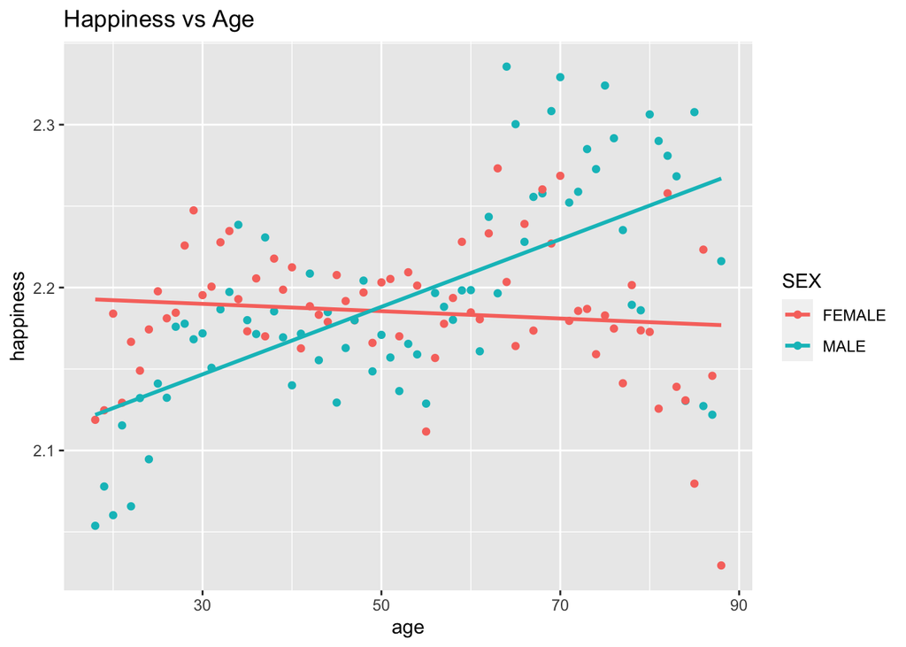

```r
ggplot(data=happy.age.sex, aes(x=age, y=m.happy2, colour=SEX)) + geom_point() +  geom_smooth(method='lm', se=FALSE) + labs(title="Happiness vs Age", y="happiness")
```

From the data, it seems that males have a positive trend when observing the relationship between age and happiness whereas femalse have a negative trend. This may be due to a few outliers that are heavily weighing down/pushing up the happiness. The male category seems to have a lower overall happiness at a younger age but grows at a steady rate to a rating of about 2.27 at its maximum when age is around 90. The female category starts at a higher overall happiness when compared to the male categoery and is steady for most of the time but declining very slowly until when age is 70 where it has a sharp decline causing the overall average happiness to decline.